# Wine clustering example

9/21/2017

```r
library(tidyverse)
library(knitr)
library(gridExtra)
library(cluster)

# load the wines dataset
wines <- read.csv('wines.csv')
colnames(wines) <- c("cultivar", "alcohol", "malic acid", "ash",
                     "alcalinity of ash", "magnesium", "total phenols",
                     "flavanoids", "nonflavanoid phenols",
                     "proanthocyanins", "color intensity", "hue",
                     "OD280/OD315 of diluted wines", "proline")
cultivar <- as.factor(wines$cultivar)
wines <- select(wines, -cultivar)

# define a function for plotting
plotLabeledData <- function(x, y, labels=NULL) {
  # Plot labeled data along two axes
  # Args:
  #   x: observation values for the first axis to plot over
  #   y: observation values for the second axis to plot over
  #   labels: factor giving the label of each point

  plotting.data <- data.frame(X = x, Y = y, label = labels)
  p <- ggplot(plotting.data) +
    geom_point(aes(x = X, y = Y, color = label))
  return(p)

}
```

The data included in this directory comes from the UCI machine learning repository ([link](https://archive.ics.uci.edu/ml/datasets/wine)). It contains information on the chemical composition of 178 wines from 3 cultivars. Your task explore and evaluate different clusterings of this data.

To achieve an “overall” view of the data, we will visualize the data projected onto the first two principal components.

# Principal component analysis

First, we must calculate the principal components.

```r
# run PCA
wines.pca <- prcomp(wines, scale=T)
```

We can look to see the variable loadings for each variable on the first two principal components.

```r
# which variables contribute most to the first two principal components?
kable(wines.pca$rotation[, 1:2])
```

|  | PC1 | PC2 |
| --- | --- | --- |
| alcohol | -0.1443294 | 0.4836515 |
| malic acid | 0.2451876 | 0.2249309 |
| ash | 0.0020511 | 0.3160688 |
| alcalinity of ash | 0.2393204 | -0.0105905 |
| magnesium | -0.1419920 | 0.2996340 |
| total phenols | -0.3946608 | 0.0650395 |
| flavanoids | -0.4229343 | -0.0033598 |
| nonflavanoid phenols | 0.2985331 | 0.0287795 |
| proanthocyanins | -0.3134295 | 0.0393017 |
| color intensity | 0.0886167 | 0.5299957 |
| hue | -0.2967146 | -0.2792351 |
| OD280/OD315 of diluted wines | -0.3761674 | -0.1644962 |
| proline | -0.2867522 | 0.3649028 |

Looking at the cumulative variability, it also looks as though the first 4 PCs explain around 74% of the variability in the data.

```r
# what is the cumulative proportion of variance explained by each PC?
cumulative_variability = cumsum(wines.pca$sdev^2) / sum(wines.pca$sdev^2)
kable(data.frame(`principal component` = 1:13,
                 `cumulative variability explained` = cumulative_variability))
```

| principal.component | cumulative.variability.explained |
| --- | --- |
| 1 | 0.3619885 |
| 2 | 0.5540634 |
| 3 | 0.6652997 |
| 4 | 0.7359900 |
| 5 | 0.8016229 |
| 6 | 0.8509812 |
| 7 | 0.8933680 |
| 8 | 0.9201754 |
| 9 | 0.9423970 |
| 10 | 0.9616972 |
| 11 | 0.9790655 |
| 12 | 0.9920479 |
| 13 | 1.0000000 |

The figure below shows the data projected onto the first two principal components, labeled by cultivar. We see that the data cluster nicely with respect to cultivar in this space.

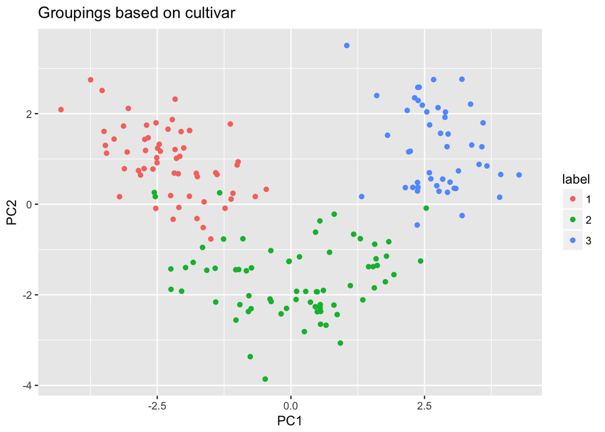

```r
# plot wine data projected onto first two PCs and compare across cultivar
plotLabeledData(wines.pca$x[, 1],
                wines.pca$x[, 2],
                labels=cultivar)   +
  ggtitle("Groupings based on cultivar") +
  xlab("PC1") +
  ylab("PC2")
```

# Clustering in raw and reduced spaces

The figure below shows the labels that result from clustering the raw data and those that result from clustering data projected onto the first two principal components. We can see that the first two PCs contain much of the information required to group by cultivar.

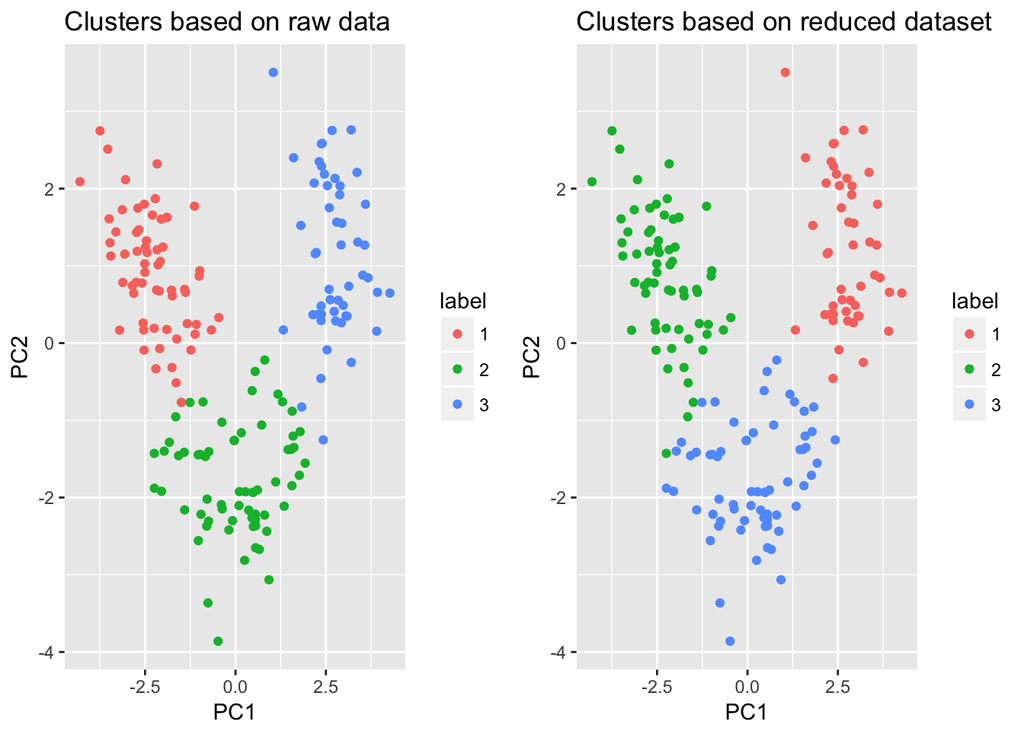

Clusterings from raw (left) and reduced (right) data

```r
# cluster wine data in original and PC spaces and plot along first two PCs
k <- 3
# k-means using all three variables
kmeans.raw <- kmeans(scale(wines), centers = k)
# spectral clustering using first 2 pc only
kmeans.reduced <- kmeans(wines.pca$x[, 1:2], centers = k)

# plot kmeans results
p.raw <- plotLabeledData(wines.pca$x[, 1], wines.pca$x[, 2],
  labels = as.factor(kmeans.raw$cluster)) +
  ggtitle("Clusters based on raw data") +
  xlab("PC1") +
  ylab("PC2")
# plot spectral clustering
p.reduced <- plotLabeledData(wines.pca$x[, 1], wines.pca$x[, 2],
  labels = as.factor(kmeans.reduced$cluster))  +
  ggtitle("Clusters based on reduced dataset") +
  xlab("PC1") +
  ylab("PC2")
grid.arrange(p.raw, p.reduced, ncol=2)
```

# Clustering with various $k$: stability

For the previous example we set $k=3$. In some sense, we cheated using the known number of cultivars to choose $k$. Typically the number of clusters is unknown and we need some way to evaluate the quality of a clustering. One useful metric for this is cluster stability: do we recover similar clusters by changing part of our analysis (e.g. using different starting points for algorithms that converge to local optima, perturbing variables). We will cover more formal metrics for stability later in the course. For now, we will use visualization to examine cluster stability. Try using the $k-$means algorithm to cluster the wine data with different values of $k$. For each $k$ run the algorithm a few times using different starting points (the kmeans function uses random starting points by default) and plot your results. What values of $k$ lead to stable clusterings?

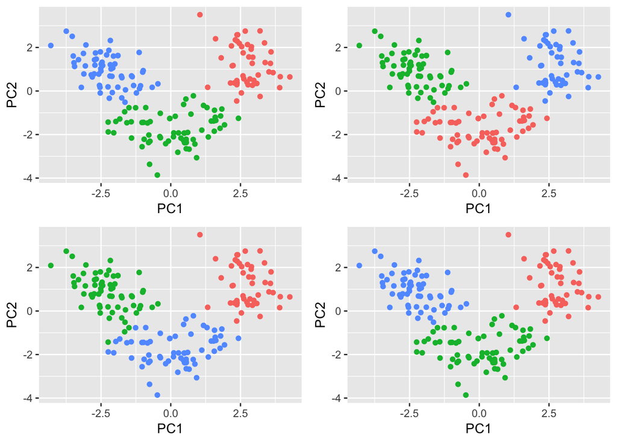

Cluster labels using k=3

```r
# run spectral clustering 4 times with 3 centers
kmeans.3 <- lapply(1:4, function(k) {
    kmeans(wines.pca$x[,1:2], centers = 3)
  })
# plot the resulting clusters from each run of spectral clustering
clusters <- lapply(kmeans.3, function(km) {
  p <- plotLabeledData(wines.pca$x[, 1], wines.pca$x[, 2],
    labels = as.factor(km$cluster))
  p <- p + theme(legend.position = "none") +
  xlab("PC1") +
  ylab("PC2")
})
grid.arrange(clusters[[1]], clusters[[2]],
             clusters[[3]], clusters[[4]],
             ncol = 2)
```

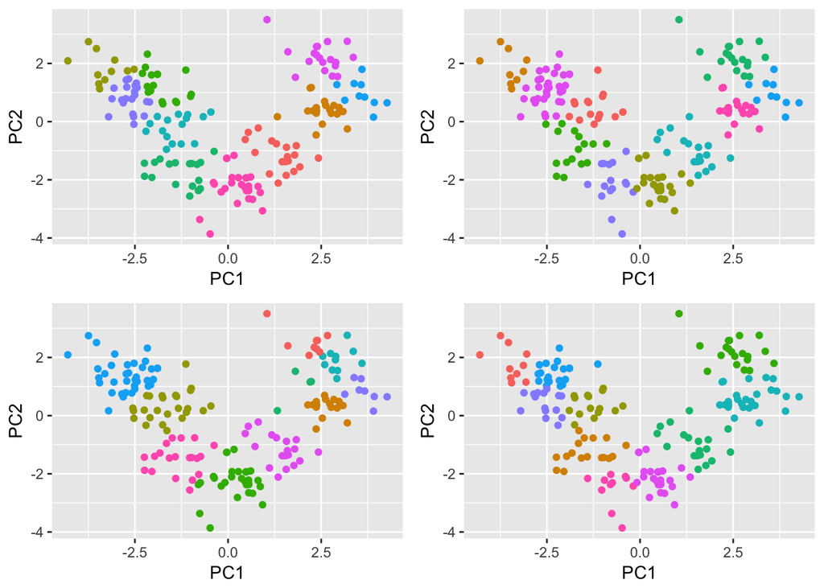

Cluster labels using k=10

```r
# re-run with 10 clusters
kmeans.10 <- lapply(1:4, function(k) {
    kmeans(wines.pca$x[ ,1:2], centers = 10)
  })
# plot the 4 runs of spectral clustering with 10 centers
clusters <- lapply(kmeans.10, function(km) {
  p <- plotLabeledData(wines.pca$x[, 1], wines.pca$x[, 2],
    labels = as.factor(km$cluster))
  p <- p + theme(legend.position = "none") +
  xlab("PC1") +
  ylab("PC2")
})
grid.arrange(clusters[[1]], clusters[[2]], clusters[[3]], clusters[[4]], ncol=2)
```

# Silhouettes

Intuitively, we expect good clusters to contain points that are close to one another and far from points in other clusters. Silhouettes are one way to measure this. Given a distance matrix and set of cluster labels, R’s silhouette function in the package cluster calculates:

$$s_{i}=\frac{b_{i}-a_{i}}{\max(a_{i}, b_{i})}$$

where $a_{i}=\sum_{j\in C_{i}} d(x_{i}, x_{j})$ is the average distance between $x_i$ and all other points belonging to the same cluster $C_{i}$ and $b{i}=\min_{C_k} \sum_{j\in C_{k}} d(x_{i}, x_{j})$ for $k\ne i$ is the average dissimilarity between $x_{i}$ and the nearest cluster to which $x_{i}$ does not belong. The figure below shows an example with $k=3$ (average silhouette width of 0.56). Try experimenting with various $k$ and plot the resulting silhouettes.

```r
# calculate a distance matrix based on the first 2 principal components
dist.mat <- dist(wines.pca$x[, 1:2])
s <- silhouette(kmeans.reduced$cluster, dist.mat)
# average silhouette width
mean(s[, 3])
```

```
## [1] 0.5610506
```

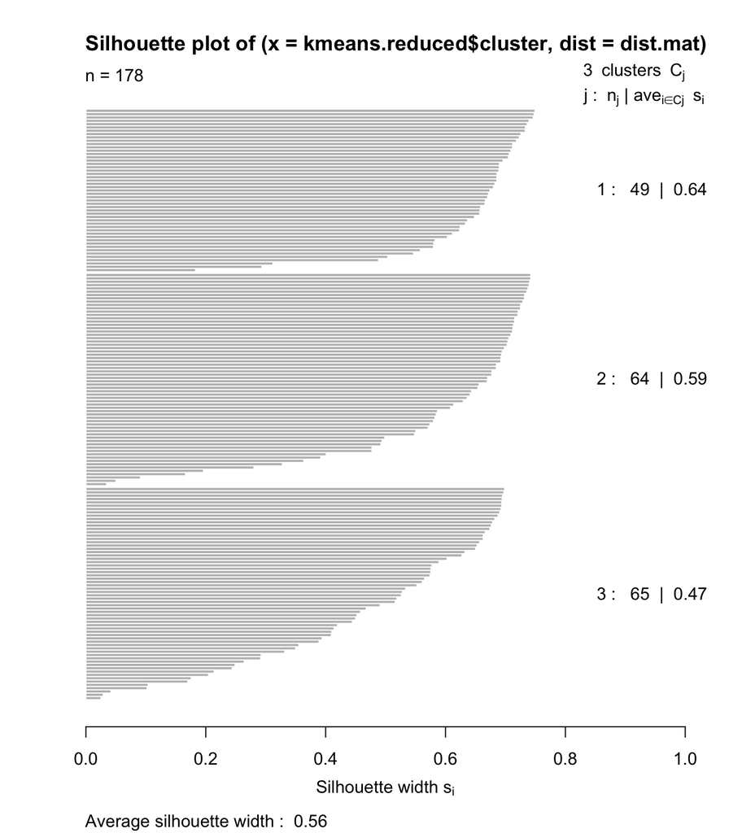

```r
plot(s)
```

Setting k = 10, we get an average silhouette width of 0.4 (implying that $k=3$ is a better choice for number of clusters).

```
## [1] 0.4104343
```

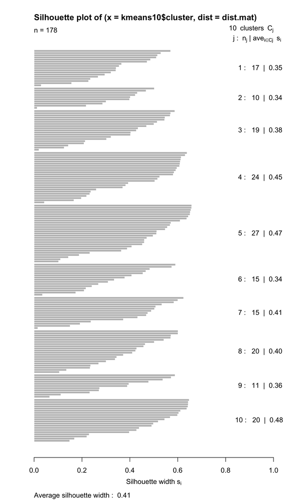

You can probably make much prettier plots than these by calculating silhouette width manually and using ggplot! These plots have terrible headings and are just generally unsatisfactory.